# Housing Market vs Stock Markets

Martin Gascon

11/01/2015

# Introduction

### Motivation and Goals

My idea was to compare the housing market with the stock market. If there is a correlation between them, I would like to know which index predicts better the Housing price and which cities are more correlated to those indexes.

Some of the various questions that I would like to answer include:

- Does the Stock Market Affect the Housing Market?
- If there is an effect effect, is this the same for different cities?
- Which index is more connected to the Housing Market?

### About the Data

- http://finance.yahoo.com/q/hp?a=03&b=1&c=2006&d=03&e=1&f=2015&g=m&s=NYA%2C+&ql=1

# Analysis

### Exploratory analysis

The exploratory analysis using R language reveals that we have around 3672 cities and 229 variables which correspond to monthly prices. I averaged the prices for each city (all zipcodes) and selected only complete cases. I also selected the close value for the market index.

### Data Processing/Results

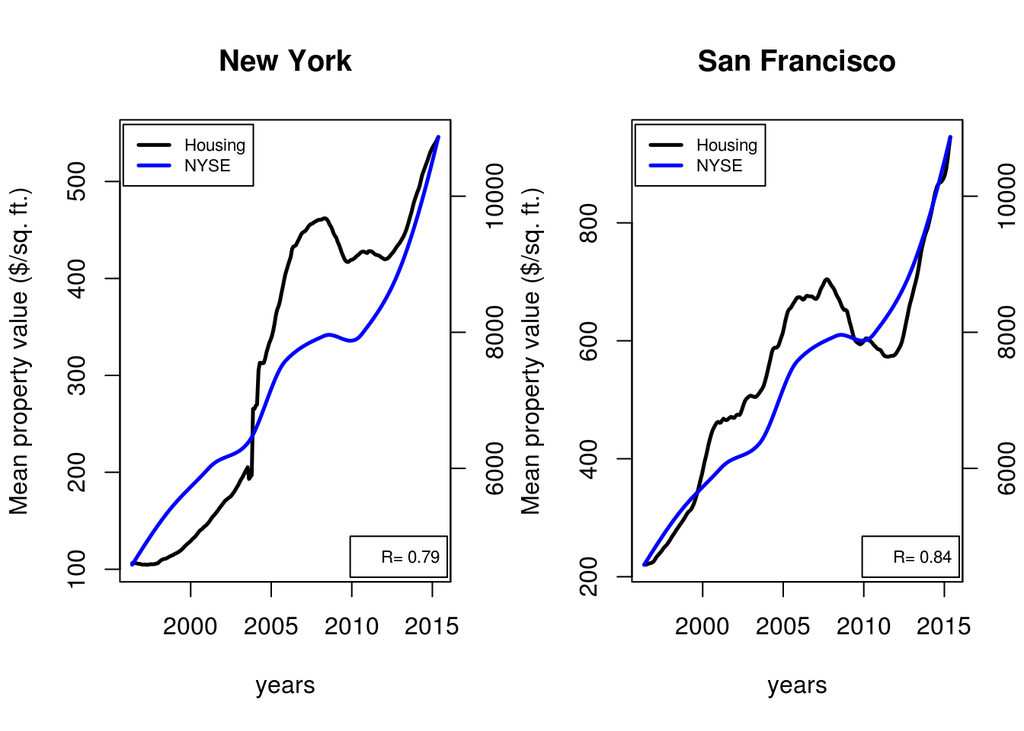

We observe that the housing and stock markets are clearly interconnected but not exactly in the same way for different cities. The Correlation for SF is higher than the one from NY (0.84 vs 0.79) even though Wall Street is in NY.

Let’s do the same comparison with the Nasdaq index.

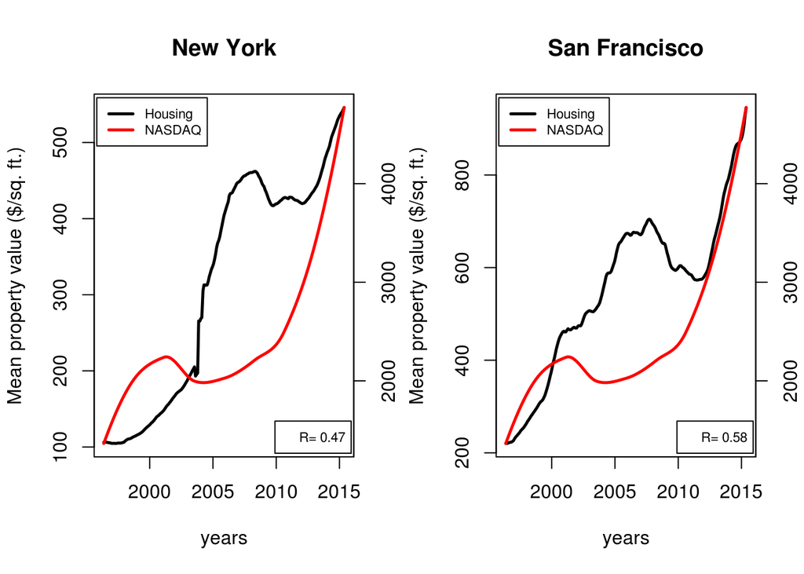

If we consider all the cities now, we can answer a few questions:

1. which cities are the 10 most expensive in the U.S.

```
##  [1] "Palo Alto"       "Los Altos"       "Menlo Park"
##  [4] "Malibu"          "Stanford"        "Burlingame"
##  [7] "San Francisco"   "Manhattan Beach" "Saratoga"
## [10] "Cupertino"
```

All in California. 8 of them in Silicon Valley.

2. which cities are the 5 least expensive in the U.S.

```
## [1] "Shenandoah"        "Town of Salamanca" "Cahokia"
## [4] "East Saint Louis"  "Youngstown"
```

3. which cities are more correlated to Dow Jones?

```
## Mountain View    Eagle Pass     Cupertino    San Carlos     Sunnyvale
##     0.8840694     0.8834987     0.8795367     0.8784956     0.8770255
```

Curiously, 3 of them have the headquarters of Google, Apple and Yahoo.

4. which cities are more correlated to NASDAQ?

```
##     Palo Alto     Hohenwald       Purcell Mountain View     Cupertino
##     0.7236257     0.7134041     0.7011296     0.6991091     0.6922888
```

In this case, we have Palo Alto which is very close to Facebook headquarters.

5. which cities are less correlated to Dow Jones?

```
##        Detroit Town of Beloit    Center Line        Redford
##     -0.4113483     -0.3460930     -0.3104341     -0.2955093
```

6. which cities are less correlated to NASDAQ?

[output not shown]

It is surprising the anticorrelation of Detroit with the Stock Markets.